# Ford GoBike System Data

## by Peter Adel Forez

# ==========================================================

## Preliminary Wrangling

> - This data set includes information about individual rides made in a bike-sharing system covering the greater San Francisco Bay area during 2019.
> - Bay Wheels is the Bay Area’s regional bicycle share system that operates in the cities of Berkeley, Emeryville, Oakland, San Jose and the city and county of San Francisco.
> - Bay Wheels(link is external) allows users to make point-to-point trips using shared bicycles.
> - The system will have at least 7,000 bicycles and 550 stations once deployment is complete.
> - The bicycles include classic pedal powered, station-based bikes, and hybrid electric bikes (ebikes), which can be docked at a station or a city bicycle rack.
> - For more information you can visit the webpage bay-area-bike-share

## Import Libraries

# ==========================================================

```python
# import all packages and set plots to be embedded inline
import numpy    as np
import pandas   as pd
import seaborn  as sb
import matplotlib.pyplot as plt

%matplotlib inline
```

```python
#Changing the size of the plots:
from matplotlib import rcParams
# Specify the figure size in inches, for both X, and Y axes
rcParams['figure.figsize'] = 15,8
```

# load the dataset in Google colab workspace

!wget https://video.udacity-data.com/topher/2020/October/5f91cf38_201902-fordgobike-tripdata/201902-fordgobike-tripdata.csv !ls

## Functions

# ==========================================================

### dataset_info

```python
def dataset_info(df):
    """
    This function provide the basic information about the dataframe.
    It provide the number of columns and rows.
    It provides the memory occuped by the DataFrame.
    It provide the datatype of the columns as well as the number of Null Values
    Paramters:
        df: The DataFrame of interest
    """
    print("The dataset contains {} rows and {} columns".
        format(df.shape[0],
              df.shape[1]))
    print("The total memory size {:.01f}MB".format(df.memory_usage(deep=True).sum()/(1024**2)))
    print("_______________________________________________________________________")
    print("The columns are:")
    max_length_columns = len(max(df.columns.to_list(), key=len))
    max_length_nan     = len(str(df.isna().sum().max()))
    max_length_dtype   = 0
    for c in df.columns:
        if max_length_dtype < len(str(df[c].dtypes)):
            max_length_dtype = len(str(df[c].dtypes))

    for i, c in enumerate (df.columns):
        print("\t{:02d} {} of type {} and has {} null values".
              format(i+1,
                    c.ljust(max_length_columns),
                    str(df[c].dtypes).ljust(max_length_dtype),
                    str(df[c].isna().sum()).ljust(max_length_nan)))
    print("_______________________________________________________________________")
```

### remove_outliers

```python
def remove_outliers(df):
    """
    This function remove the ouliers rows by ising the interquartile range (IQR)
    For more information about the function check the link: https://towardsdatascience.com/ways-to-detect-and-remove-the-outliers-404d16608dba
    Paramters:
        df: The DataFrame of interest
    """
    import pandas as pd
    print("Start: shape of data set", df.shape)
    # Separate your data into parts with numerical and categorical features
    num_df = df.select_dtypes(include=["number"])
    cat_df = df.select_dtypes(exclude=["number"])
    # IQR
    Q1 = num_df.quantile(0.25)
    Q3 = num_df.quantile(0.75)
    IQR = Q3 - Q1
    idx = ~((num_df < (Q1 - 1.5 * IQR)) | (num_df > (Q3 + 1.5 * IQR))).any(axis=1)
    df = pd.concat([num_df.loc[idx], cat_df.loc[idx]], axis=1)
    print("End  : shape of data set", df.shape)
    return df
```

### geo_distance

```python
def geo_distance(latitude1, longitude1, latitude2, longitude2):
    """
    This Function find the distance between two point on the map
    For more information about the function check the link: https://www.kite.com/python/answers/how-to-find-the-distance-between-two-lat-long-coordinates-in-python
    Paramters:
        latitude1:  First  Point Latitude
        longitude1: First  Point Longitude
        latitude2:  Second Point Latitude
        longitude2: Second Point Longitude
    """
    from math import sin, cos, sqrt, atan2, radians

    # approximate radius of earth in km
    R = 6373

    lat1 = radians(latitude1)
    lon1 = radians(longitude2)
    lat2 = radians(latitude2)
    lon2 = radians(longitude2)

    dlon = lon2 - lon1
    dlat = lat2 - lat1

    a = sin(dlat / 2)**2 + cos(lat1) * cos(lat2) * sin(dlon / 2)**2
    c = 2 * atan2(sqrt(a), sqrt(1 - a))

    distance = R * c

    return distance
```

## Import dataset

# ==========================================================

```python
bike = pd.read_csv("201902-fordgobike-tripdata.csv")
# Read the Basic information of the dataset
dataset_info(bike)
```

```
The dataset contains 183412 rows and 16 columns
The total memory size 102.7MB
_______________________________________________________________________
The columns are:
	01 duration_sec            of type int64   and has 0    null values
	02 start_time              of type object  and has 0    null values
	03 end_time                of type object  and has 0    null values
	04 start_station_id        of type float64 and has 197  null values
	05 start_station_name      of type object  and has 197  null values
	06 start_station_latitude  of type float64 and has 0    null values
	07 start_station_longitude of type float64 and has 0    null values
	08 end_station_id          of type float64 and has 197  null values
	09 end_station_name        of type object  and has 197  null values
	10 end_station_latitude    of type float64 and has 0    null values
	11 end_station_longitude   of type float64 and has 0    null values
	12 bike_id                 of type int64   and has 0    null values
	13 user_type               of type object  and has 0    null values
	14 member_birth_year       of type float64 and has 8265 null values
	15 member_gender           of type object  and has 8265 null values
	16 bike_share_for_all_trip of type object  and has 0    null values
_______________________________________________________________________
```

```python
# Explore the first 5 rows
bike.head()
```

|  | duration_sec | start_time | end_time | start_station_id | start_station_name | start_station_latitude | start_station_longitude | end_station_id | end_station_name | end_station_latitude | end_station_longitude | bike_id | user_type | member_birth_year | member_gender | bike_share_for_all_trip |
| --- | --- | --- | --- | --- | --- | --- | --- | --- | --- | --- | --- | --- | --- | --- | --- | --- |
| 0 | 52185 | 2019-02-28 17:32:10.1450 | 2019-03-01 08:01:55.9750 | 21.0 | Montgomery St BART Station (Market St at 2nd St) | 37.789625 | -122.400811 | 13.0 | Commercial St at Montgomery St | 37.794231 | -122.402923 | 4902 | Customer | 1984.0 | Male | No |
| 1 | 42521 | 2019-02-28 18:53:21.7890 | 2019-03-01 06:42:03.0560 | 23.0 | The Embarcadero at Steuart St | 37.791464 | -122.391034 | 81.0 | Berry St at 4th St | 37.775880 | -122.393170 | 2535 | Customer | NaN | NaN | No |
| 2 | 61854 | 2019-02-28 12:13:13.2180 | 2019-03-01 05:24:08.1460 | 86.0 | Market St at Dolores St | 37.769305 | -122.426826 | 3.0 | Powell St BART Station (Market St at 4th St) | 37.786375 | -122.404904 | 5905 | Customer | 1972.0 | Male | No |
| 3 | 36490 | 2019-02-28 17:54:26.0100 | 2019-03-01 04:02:36.8420 | 375.0 | Grove St at Masonic Ave | 37.774836 | -122.446546 | 70.0 | Central Ave at Fell St | 37.773311 | -122.444293 | 6638 | Subscriber | 1989.0 | Other | No |
| 4 | 1585 | 2019-02-28 23:54:18.5490 | 2019-03-01 00:20:44.0740 | 7.0 | Frank H Ogawa Plaza | 37.804562 | -122.271738 | 222.0 | 10th Ave at E 15th St | 37.792714 | -122.248780 | 4898 | Subscriber | 1974.0 | Male | Yes |

```python
# Explore the statistics of the numeric columns
bike.describe()
```

|  | duration_sec | start_station_id | start_station_latitude | start_station_longitude | end_station_id | end_station_latitude | end_station_longitude | bike_id | member_birth_year |
| --- | --- | --- | --- | --- | --- | --- | --- | --- | --- |
| count | 183412.000000 | 183215.000000 | 183412.000000 | 183412.000000 | 183215.000000 | 183412.000000 | 183412.000000 | 183412.000000 | 175147.000000 |
| mean | 726.078435 | 138.590427 | 37.771223 | -122.352664 | 136.249123 | 37.771427 | -122.352250 | 4472.906375 | 1984.806437 |
| std | 1794.389780 | 111.778864 | 0.099581 | 0.117097 | 111.515131 | 0.099490 | 0.116673 | 1664.383394 | 10.116689 |
| min | 61.000000 | 3.000000 | 37.317298 | -122.453704 | 3.000000 | 37.317298 | -122.453704 | 11.000000 | 1878.000000 |
| 25% | 325.000000 | 47.000000 | 37.770083 | -122.412408 | 44.000000 | 37.770407 | -122.411726 | 3777.000000 | 1980.000000 |
| 50% | 514.000000 | 104.000000 | 37.780760 | -122.398285 | 100.000000 | 37.781010 | -122.398279 | 4958.000000 | 1987.000000 |
| 75% | 796.000000 | 239.000000 | 37.797280 | -122.286533 | 235.000000 | 37.797320 | -122.288045 | 5502.000000 | 1992.000000 |
| max | 85444.000000 | 398.000000 | 37.880222 | -121.874119 | 398.000000 | 37.880222 | -121.874119 | 6645.000000 | 2001.000000 |

### What is the structure of your dataset?

> - The **original dataset** contains 183412 rows and 16 columns
> - The columns are ['duration_sec', 'start_time', 'end_time', 'start_station_id', 'start_station_name', 'start_station_latitude', 'start_station_longitude', 'end_station_id', 'end_station_name', 'end_station_latitude', 'end_station_longitude', 'bike_id', 'user_type', 'member_birth_year', 'member_gender', 'bike_share_for_all_trip']
> - There are some columns with null values and need to be cleaned.
> - The data types for the time need to be updated.
> - We need to add more columns for features like: age of rider, start_date and start_hour, distance...

### What is/are the main feature(s) of interest in your dataset?

> - I am more interested in knowing the features that are affecting the duration of the ride.

### What features in the dataset do you think will help support your investigation into your feature(s) of interest?

> - The feature that will helps are age, gender, start_date, start_hour and distance between stations

## Data Cleaning

# ==========================================================

### 1. Drop the Null values

```python
bike.dropna(inplace = True)
```

### 2. Drop the "Other" in member gender

```python
bike = bike[bike.member_gender != "Other"]
```

```python
bike['member_gender'] = pd.Categorical(bike['member_gender'], categories=
    ['Male','Female'],
    ordered=True)
```

### 3. Create a column for the rider age

```python
bike.member_birth_year = bike.member_birth_year.astype(int)
bike["age"] = 2019 - bike.member_birth_year
```

### 4. Drop the rider older than 80

```python
bike = bike[bike.age < 80]
```

### 5. Create a columns for the day and hour of the ride

```python
bike.start_time = pd.to_datetime(bike.start_time)
bike.end_time   = pd.to_datetime(bike.end_time)

bike["start_day"] = bike["start_time"].dt.day_name()
bike["end_day"]   = bike["end_time"]  .dt.day_name()

bike['start_day'] = pd.Categorical(bike['start_day'], categories=
    ['Monday','Tuesday','Wednesday','Thursday','Friday','Saturday', 'Sunday'],
    ordered=True)

bike['end_day'] = pd.Categorical(bike['end_day'], categories=
    ['Monday','Tuesday','Wednesday','Thursday','Friday','Saturday', 'Sunday'],
    ordered=True)

bike["start_hour"] = bike["start_time"].dt.hour
bike["end_hour"]   = bike["end_time"]  .dt.hour
```

### 6. Create a column for different return station

```python
bike["return_station"] = "different_return"
bike.loc[bike.start_station_name == bike.end_station_name, "return_station"] = "same_return"
```

### 7. Create a column for the distance traveled

```python
bike["distance"] = bike.apply(lambda x: geo_distance(x.start_station_latitude, x.start_station_longitude, x.end_station_latitude, x.end_station_longitude), axis =1)
```

### 8. Convert the end and start station id to int

```python
bike['start_station_id']=bike['start_station_id'].astype(int)
bike['end_station_id']  =bike['end_station_id'].astype(int)
```

### 9. Remove Outliers using IQR Score

```python
bike = remove_outliers(bike)
```

```
Start: shape of data set (171105, 23)
End  : shape of data set (115990, 23)
```

### Check the info for the cleaned dataset

```python
dataset_info(bike)
```

```
The dataset contains 115990 rows and 23 columns
The total memory size 53.4MB
_______________________________________________________________________
The columns are:
	01 duration_sec            of type int64          and has 0 null values
	02 start_station_id        of type int32          and has 0 null values
	03 start_station_latitude  of type float64        and has 0 null values
	04 start_station_longitude of type float64        and has 0 null values
	05 end_station_id          of type int32          and has 0 null values
	06 end_station_latitude    of type float64        and has 0 null values
	07 end_station_longitude   of type float64        and has 0 null values
	08 bike_id                 of type int64          and has 0 null values
	09 member_birth_year       of type int32          and has 0 null values
	10 age                     of type int32          and has 0 null values
	11 start_hour              of type int64          and has 0 null values
	12 end_hour                of type int64          and has 0 null values
	13 distance                of type float64        and has 0 null values
	14 start_time              of type datetime64[ns] and has 0 null values
	15 end_time                of type datetime64[ns] and has 0 null values
	16 start_station_name      of type object         and has 0 null values
	17 end_station_name        of type object         and has 0 null values
	18 user_type               of type object         and has 0 null values
	19 member_gender           of type category       and has 0 null values
	20 bike_share_for_all_trip of type object         and has 0 null values
	21 start_day               of type category       and has 0 null values
	22 end_day                 of type category       and has 0 null values
	23 return_station          of type object         and has 0 null values
_______________________________________________________________________
```

```python
# Save the cleaned dataset into external csv
bike.to_csv('clean_bikes.csv', index  = False)
```

```python
print(bike.columns)
```

```
Index(['duration_sec', 'start_station_id', 'start_station_latitude',
       'start_station_longitude', 'end_station_id', 'end_station_latitude',
       'end_station_longitude', 'bike_id', 'member_birth_year', 'age',
       'start_hour', 'end_hour', 'distance', 'start_time', 'end_time',
       'start_station_name', 'end_station_name', 'user_type', 'member_gender',
       'bike_share_for_all_trip', 'start_day', 'end_day', 'return_station'],
      dtype='object')
```

### What is the structure of your dataset?

> - The **cleaned dataset** contains 115990 rows and 23 columns
> - The columns are ['duration_sec', 'start_station_id', 'start_station_latitude', 'start_station_longitude', 'end_station_id', 'end_station_latitude', 'end_station_longitude', 'bike_id', 'member_birth_year', 'age', 'start_hour', 'end_hour', 'distance', 'start_time', 'end_time', 'start_station_name', 'end_station_name', 'user_type', 'member_gender', 'bike_share_for_all_trip', 'start_day', 'end_day', 'return_station']

### What is/are the main feature(s) of interest in your dataset?

> - The main feature is the duration of the ride.

### What features in the dataset do you think will help support your investigation into your feature(s) of interest?

> - The feature that will helps are age, gender, start_date and start_hour.

## Univariate Exploration

# ==========================================================

### Distribution of the ride duration

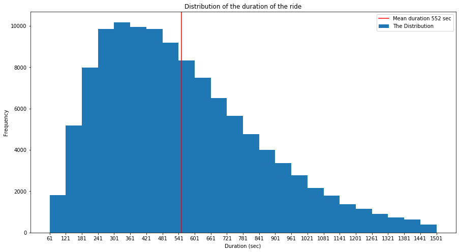

```python
step = 60
bins = np.arange(bike.duration_sec.min(),
                 bike.duration_sec.max()+step,
                 step)
# Historgram of the distribution of the duration
plt.hist(data = bike, x="duration_sec", bins = bins, label = "The Distribution");
# Vertical line specifying the mean
plt.axvline(x=bike.duration_sec.mean(),
            label = "Mean duration {:0.0f} sec".format(bike.duration_sec.mean()),
            color = "red")

plt.xlabel("Duration (sec)");
plt.ylabel("Frequency");
plt.xticks(bins, bins)
plt.title("Distribution of the duration of the ride")
plt.legend();
```

> Insights:  
> We are intended to see the distribution of the ride duration and know the shape and average values.
> - The above curve is normal distribution but skewed to the right.
> - The average duration of the ride is around 600s or 10min. </font>

### Distribution of the distance travelled

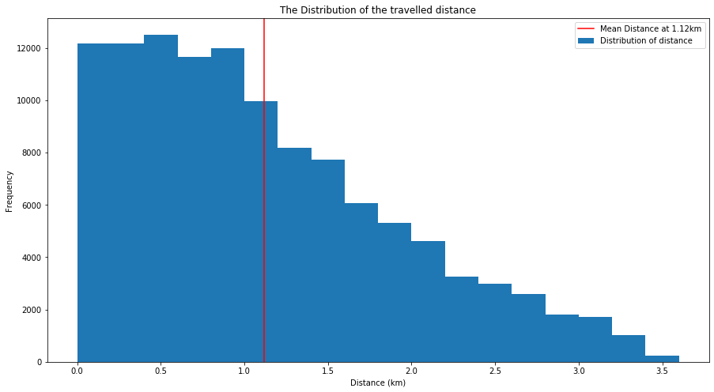

```python
step = 0.2
bins = np.arange(bike.distance.min(), bike.distance.max()+step, step)

# Historgram of the distribution of the distance
plt.hist(data = bike, x="distance", bins = bins, label = "Distribution of distance");
# Vertical line specifying the mean
plt.axvline(x=bike.distance.mean(),
            label = "Mean Distance at {:0.2f}km".format(bike.distance.mean()),
            color = "red")

plt.xlabel("Distance (km)");
plt.ylabel("Frequency");
plt.title("The Distribution of the travelled distance")
plt.legend();
```

### Distribution of member age

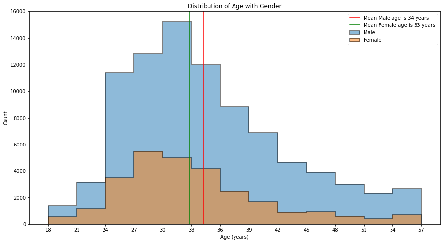

```python
step = 3
bins = np.arange(bike.age.min(), bike.age.max()+step, step)
kwargs = dict(histtype='stepfilled', alpha=0.5, edgecolor="black", linewidth=2)

plt.hist(data=bike[bike.member_gender == "Male"], x="age",
         bins= bins, label = "Male", **kwargs);
plt.hist(data=bike[bike.member_gender == "Female"], x="age",
         bins= bins, label = "Female", **kwargs);
#sb.displot(data=bike, x="age", bins= bins, hue = "member_gender", kde=True);
plt.axvline(x=bike.groupby("member_gender").age.mean().Male,
            label = "Mean Male age is {:0.0f} years".format(bike.groupby("member_gender").age.mean().Male),
            color = "red")
plt.axvline(x=bike.groupby("member_gender").age.mean().Female,
            label = "Mean Female age is {:0.0f} years".format(bike.groupby("member_gender").age.mean().Female),
            color = "green")
plt.legend(loc = 'upper right');
plt.xlabel("Age (years)");
plt.ylabel("Count");
plt.title("Distribution of Age with Gender")
plt.xticks(bins, bins);
```

> Insights:
> - The distribution of the rider age is normal distibution but right skewed.
> - The average age is around 33 years old.
> - The number of Male rider are much more than the Femals riders. </font>

### Distribution of start and end bike riding

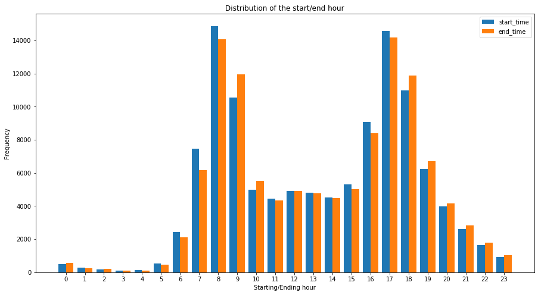

```python
plt.bar(bike["start_time"].dt.hour.value_counts().index,
        height = bike["start_time"].dt.hour.value_counts(),
        align = "edge",
        width = -0.4,
        label = "start_time")
plt.bar(bike["end_time"].dt.hour.value_counts().index,
        height = bike["end_time"].dt.hour.value_counts(),
        align = "edge",
        width = 0.4,
        label = "end_time")

ticks = range(0,24)
labels = ['{}'.format(v) for v in ticks]
plt.xticks(ticks, labels);

plt.xlabel("Starting/Ending hour")
plt.ylabel("Frequency")
plt.title("Distribution of the start/end hour")
plt.legend();
```

```python
# Find the peak hours
bike.start_hour.value_counts()[:4]
```

```
8     14871
17    14556
18    10997
9     10556
Name: start_hour, dtype: int64
```

> Insights:
> - The distribution of the start_hour and end_hour are similar.
> - The peak in the morning is at 8:00AM and 9:00AM
> - The peak in the evening is at 5:00PM and 6:00PM
> - It appears that the peak is during going to work from home and return back from work to home. </font>

### Distribution of Day of the week

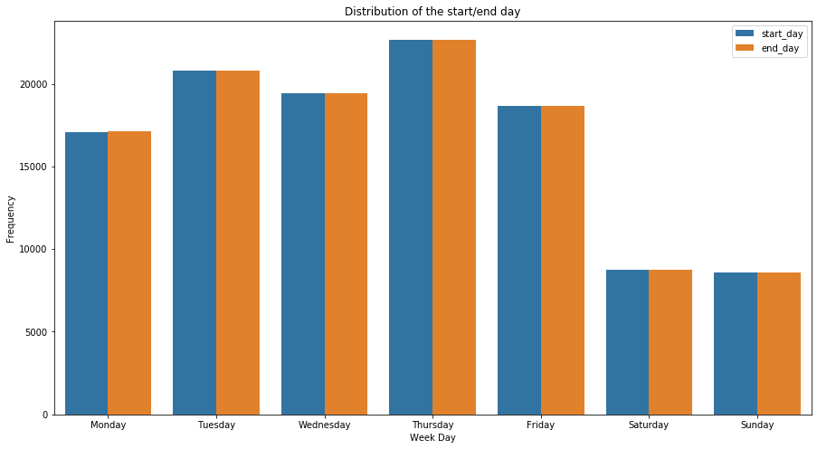

```python
# https://stackoverflow.com/questions/46223224/matplotlib-plot-countplot-for-two-or-more-column-on-single-plot
sb.countplot(x="value", hue="variable", data=pd.melt(bike[["start_day", "end_day"]]),
             order = ['Monday','Tuesday','Wednesday','Thursday','Friday','Saturday', 'Sunday']);
plt.xlabel("Week Day")
plt.ylabel("Frequency")
plt.title("Distribution of the start/end day")

plt.legend();
```

> Insights:
> - During the working day, the rides are twice the weekend.
> - This indicates that the bike sharing is used for going to work and vice versa. </font>

### Distribution of bike gender

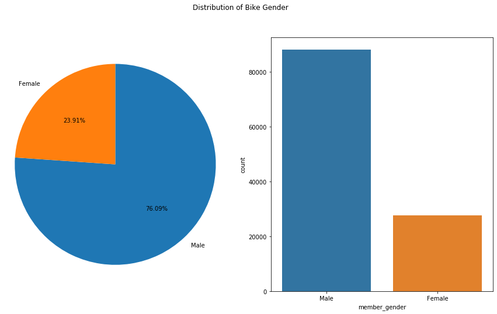

```python
plt.subplot(1,2,1)
plt.pie(bike.member_gender.value_counts(),
        labels = bike.member_gender.value_counts().index ,
        startangle = 90,
        counterclock = False,
        autopct='%1.2f%%');
plt.axis('square');

plt.subplot(1,2,2)
sb.countplot(data = bike, x = "member_gender");

plt.suptitle("Distribution of Bike Gender");
```

> Insights:
> - 24% of bike user are Female.
> - 76% of bike user are Male.
> - We need to add promotion for women to encourage them. </font>

### Distribution of user_type

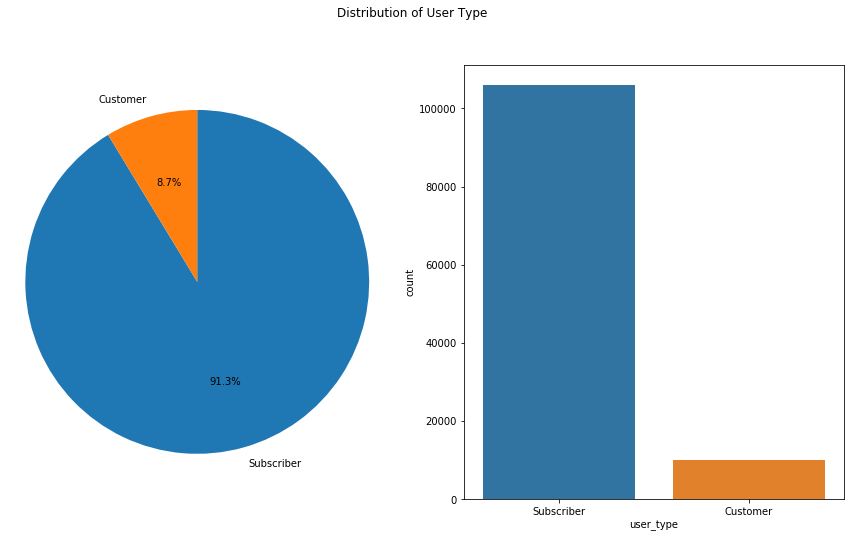

```python
plt.subplot(1,2,1)
plt.pie(bike.user_type.value_counts(),
        labels = bike.user_type.value_counts().index ,
        startangle = 90,
        counterclock = False,
        autopct='%1.1f%%');
plt.axis('square');

plt.subplot(1,2,2)
sb.countplot(data = bike, x = "user_type");
plt.suptitle("Distribution of User Type");
```

> Insights:
> - 09% of bike user are Customer.
> - 91% of bike user are Subscriber. </font>

### Bar Char return_station

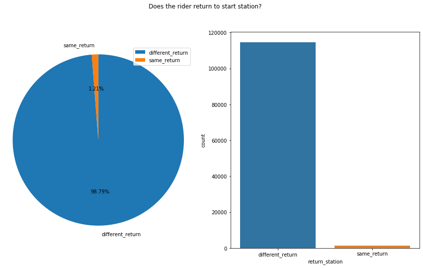

```python
plt.subplot(1,2,1)
plt.pie(bike.return_station.value_counts(),
        labels = bike.return_station.value_counts().index ,
        startangle = 90,
        counterclock = False,
        autopct='%1.2f%%');
plt.axis('square');
plt.legend();

plt.subplot(1,2,2)
sb.countplot(data = bike, x = "return_station");

plt.suptitle("Does the rider return to start station?");
```

> Insights:
> - 01% of rider return to the start station.
> - 99% of rider return different stations. </font>

### Distribution of bike_share_for_all_trip

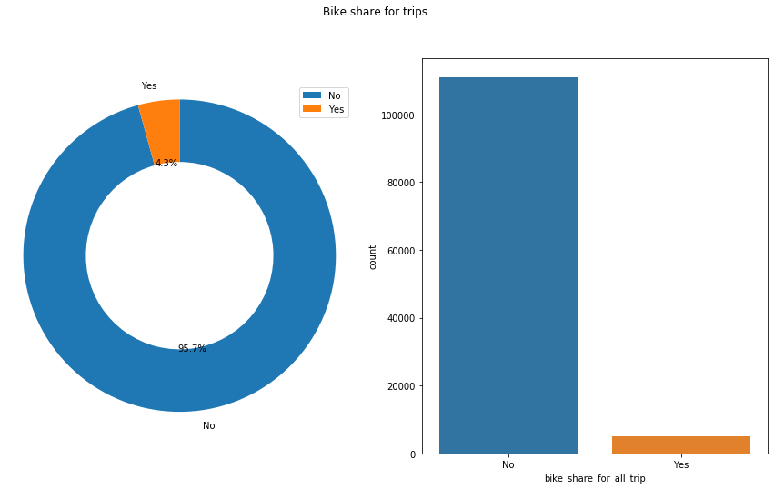

```python
plt.subplot(1,2,1)
plt.pie(bike.bike_share_for_all_trip.value_counts(),
        labels = bike.bike_share_for_all_trip.value_counts().index ,
        startangle = 90,
        counterclock = False,
        autopct='%1.1f%%',
        wedgeprops = {'width' : 0.4});
plt.axis('square');
plt.legend();

plt.subplot(1,2,2)
sb.countplot(data = bike, x = "bike_share_for_all_trip");
plt.suptitle("Bike share for trips");
```

### Discuss the distribution(s) of your variable(s) of interest. Were there any unusual points? Did you need to perform any transformations?

> - The rider uses the bike to go to work and return back and here are the evidence:
>   1. The average age of rider is 33 years.
>   2. The average ride time is 10min which indicate that the office is relatively close to home.
>   3. 99% of rider return different stations.
>   4. 91% of bike user are Subscriber
>   5. During the weekend, the number of rides decrease to half.
>   6. Most of the rider are Male.
>   7. The peak hours are:  
>      a. 8:00AM and 9:00AM in the morning.  
>      b. 5:00PM and 6:00PM at the evening.

### Of the features you investigated, were there any unusual distributions? Did you perform any operations on the data to tidy, adjust, or change the form of the data? If so, why did you do this?

> - In the dataset, there is some Null value .
>   - We dropped them as their number is relatively small.
> - In the column of member gender, some of the values are denoted as "others".
>   - We dropped them as these are wrong rows.
> - Created a column for the rider age because it will be more informative than the member birth year.
>   - We dropped the rows with age more than 80 years.
> - Create columns for the day and the hour of the ride.
> - Create a column to detect that the start and end stations are not the same.
> - We used the IQR score to remove Outliers.

## Bivariate Exploration

# ==========================================================

### Relation between start day and end day

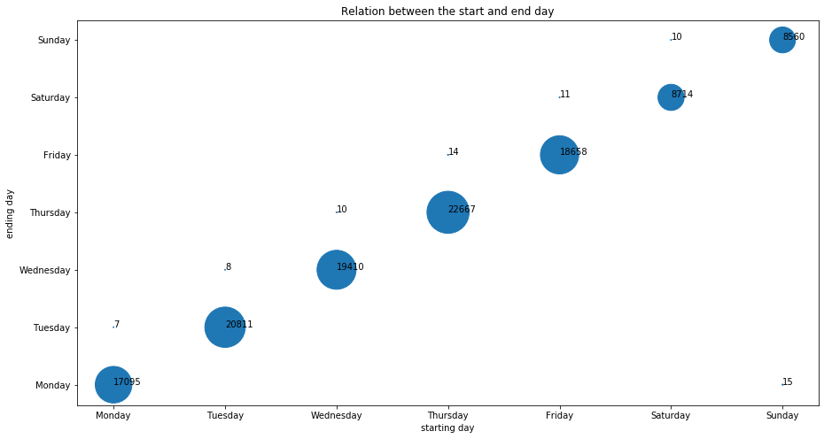

```python
Temp = bike.groupby(["start_day", "end_day"]).size().reset_index()
Temp.columns = ["start_day", "end_day", "size"]

fig, ax = plt.subplots()
ax.scatter(data = Temp,
            x = "start_day",
            y = "end_day",
            s = Temp["size"]/10,
            vmin = 1);
plt.xlabel("starting day");
plt.ylabel("ending day");
for i, txt in enumerate(Temp["size"]):
  if Temp["size"][i]>0:
    ax.annotate(txt, (Temp.start_day[i], Temp.end_day[i]))
plt.title("Relation between the start and end day");
```

```python
(bike.start_day == bike.end_day).sum()/bike.shape[0], (bike.start_day != bike.end_day).sum()/bike.shape[0]
```

```
(0.9993533925338391, 0.000646607466160876)
```

> Insights:
> - Most of the Bike are used for only one day.
> - Very Few of the Bike are returned the next day.
> - The weekend use of the bike are less then the half of working days. </font>

### Relation between user type and the duration

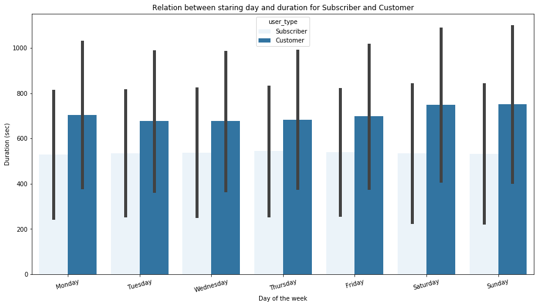

```python
base_color = sb.color_palette()[0]
sb.barplot(data=bike, x='start_day', y='duration_sec', hue="user_type",
           color=base_color,
           errwidth=5,
           ci='sd')
plt.xticks(rotation=15);
plt.xlabel("Day of the week");
plt.ylabel("Duration (sec)");
plt.title("Relation between staring day and duration for Subscriber and Customer");
```

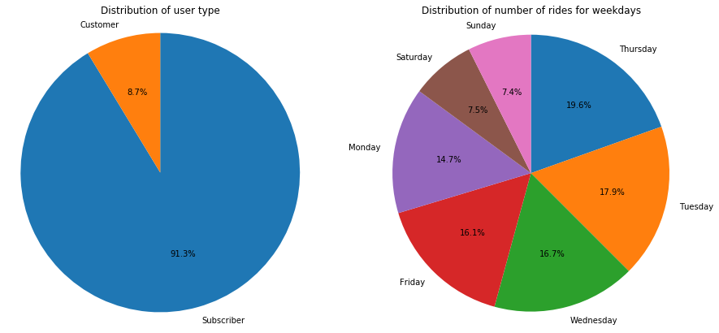

```python
###############################################################################
plt.subplot(1,2,1)
plt.pie(bike.user_type.value_counts(),
        labels = bike.user_type.value_counts().index ,
        startangle = 90,
        counterclock = False,
        autopct='%1.1f%%');
plt.axis('square');
plt.title("Distribution of user type");
###############################################################################
plt.subplot(1,2,2)
plt.pie(bike.start_day.value_counts(),
        labels = bike.start_day.value_counts().index ,
        startangle = 90,
        counterclock = False,
        autopct='%1.1f%%');
plt.axis('square');
plt.title("Distribution of number of rides for weekdays");
```

> Insights:
> - Average duration of "Customer" is heigher than "Subscriber".
> - Average Duration of the ride is around 600ms or 10min. </font>

## Multivariate Exploration

# ==========================================================

### Starting time during weekdays

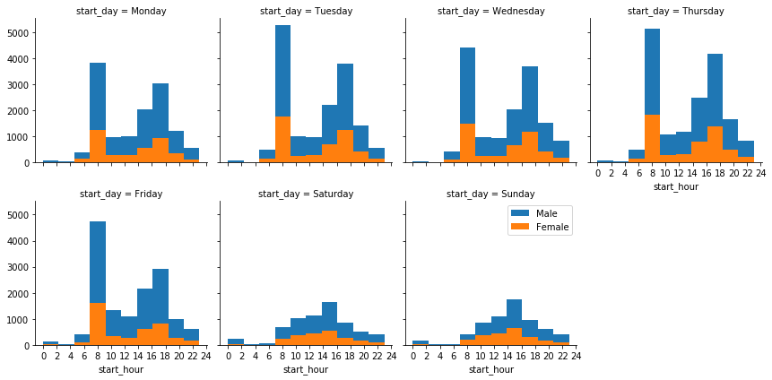

```python
g = sb.FacetGrid(data = bike, col = 'start_day', col_wrap=4, sharey=True, hue = "member_gender")
g.map(plt.hist, 'start_hour');
ticks = range(0,24+2,2)
labels = ['{}'.format(v) for v in ticks]
plt.xticks(ticks, labels);
plt.legend();
```

> Insights:
> - During working days:
>   - The peak in the morning is at 8:00AM and 9:00AM
>   - The peak in the evening is at 5:00PM and 6:00PM
> - During weekends:
>   - The peek is arund 2:00PM </font>

### Relation between distance, duration and gender

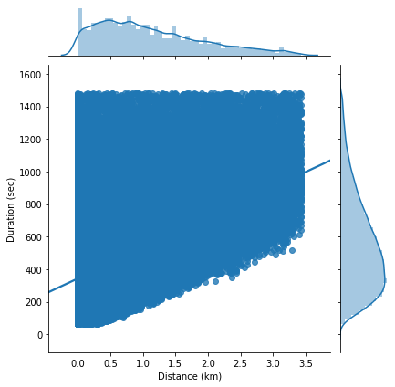

```python
sb.jointplot(data = bike, x = "distance", y = "duration_sec", kind = "reg");
plt.xlabel("Distance (km)");
plt.ylabel("Duration (sec)");
```

> Insights:
> - The duration of the ride increase with distance. </font>

### Relation between age, duration and weekday

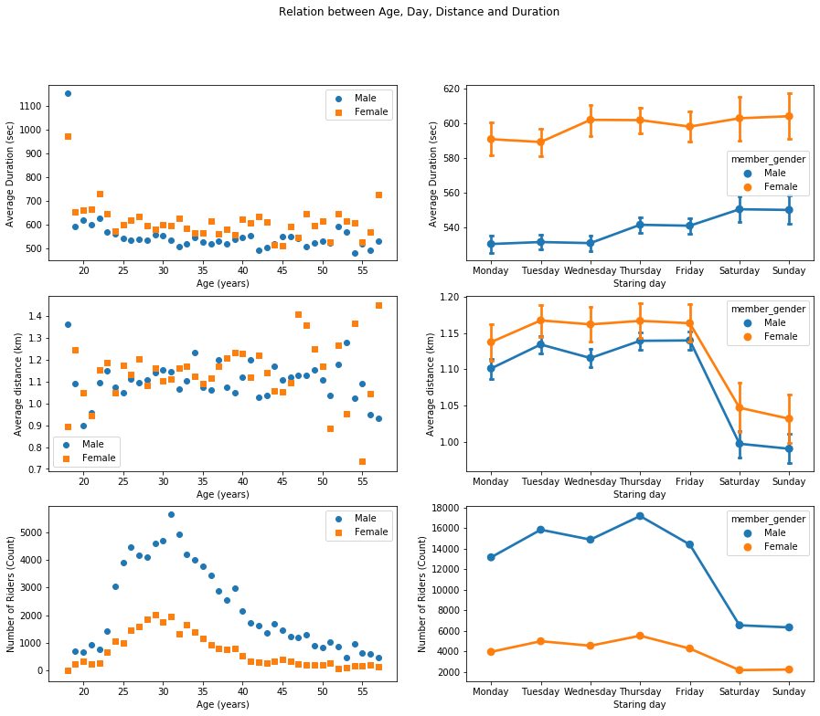

```python
cat_markers = [['Male', 'o'],
               ['Female', 's']]
plt.figure(figsize=(15,12))
################################################################################
plt.subplot(3,2,1)
df_temp = bike.groupby(["member_gender", "age"]).duration_sec.mean().reset_index()

for cat, marker in cat_markers:
    df_cat = df_temp[df_temp['member_gender'] == cat]
    plt.scatter(data = df_cat, x = 'age', y = 'duration_sec',
                marker = marker)
plt.legend(['Male','Female']);
plt.xlabel("Age (years)");
plt.ylabel("Average Duration (sec)");
################################################################################
plt.subplot(3,2,2)
sb.pointplot(data = bike, x = 'start_day', y = 'duration_sec',
             hue = "member_gender", marker = marker, capsize=.05)
plt.xlabel("Staring day");
plt.ylabel("Average Duration (sec)");
################################################################################
plt.subplot(3,2,3)
df_temp = bike.groupby(["member_gender", "age"]).distance.mean().reset_index()

for cat, marker in cat_markers:
    df_cat = df_temp[df_temp['member_gender'] == cat]
    plt.scatter(data = df_cat, x = 'age', y = 'distance',
                marker = marker)
plt.legend(['Male','Female']);
plt.xlabel("Age (years)");
plt.ylabel("Average distance (km)");
################################################################################
plt.subplot(3,2,4)
sb.pointplot(data = bike, x = 'start_day', y = 'distance',
             hue = "member_gender", marker = marker, capsize=.05);
plt.xlabel("Staring day");
plt.ylabel("Average distance (km)");
################################################################################
plt.subplot(3,2,5)
df_temp = bike.groupby(["member_gender", "age"]).duration_sec.size().reset_index()

for cat, marker in cat_markers:
    df_cat = df_temp[df_temp['member_gender'] == cat]
    plt.scatter(data = df_cat, x = 'age', y = 'duration_sec',
                marker = marker)
plt.legend(['Male','Female']);
plt.xlabel("Age (years)");
plt.ylabel("Number of Riders (Count)");
################################################################################
plt.subplot(3,2,6)
sb.pointplot(data = bike.groupby(["member_gender", "start_day"]).duration_sec.size().reset_index(),
             x = 'start_day', y = 'duration_sec',
             hue = "member_gender", marker = marker)
plt.xlabel("Staring day");
plt.ylabel("Number of Riders (Count)");

plt.suptitle("Relation between Age, Day, Distance and Duration");
```

> Insights:
> - The average duration and distance of a ride for Female is greater than Male over the week.
> - The number of rides for Male is greater than the Female over the week. </font>

### Talk about some of the relationships you observed in this part of the investigation. Were there features that strengthened each other in terms of looking at your feature(s) of interest?

> - The duration of the ride increase with distance.
> - The average duration and distance of a ride for Female is greater than Male over the week.
> - The number of rides for Male is greater than the Female over the week.
> - During working days:
>   - The peak in the morning is at 8:00AM and 9:00AM
>   - The peak in the evening is at 5:00PM and 6:00PM
> - During weekends:
>   - The peek is arund 2:00PM